# Querying Data From ODS

Emma Jones

3/17/2022

There are a few general concepts to be aware of when querying data from ODS. These include connecting and disconnecting from a database, understanding the underlying data schema, how data “Views” interact with one another, and data update frequencies. This module deals exclusively with data from the ODS production environment. Please see the Connect to ODS section for information about the test vs production environments.

In an ideal world, one would practice querying data against a test environment and only query the production environment for official data retrievals. This is especially true when building automated reports or applications that could repeatedly tax the database with frequent large queries during the development process. **However,** due to frequency of data updates to the ODStest environment and potential schema differences, we do not encourage users to rely on data in this environment.

### Connecting and Disconnecting from a Database

It is imperative to understand that each time a user connects to a database it is that user’s responsibility to disconnect from the database once they have finished their database operations. Forgotten open database connections (or “leaked connections”) unnecessarily tax a database and are poor practice as programmers. Below are example connection and disconnection statements based on how a user may connect to a database.

```r
# Connect using the DBI library
con <- dbConnect(odbc::odbc(),
                 .connection_string = "driver={ODBC Driver 11 for SQL Server};server={DEQ-SQLODS-PROD,50000};database={ODS};trusted_connection=yes")
# Disconnect using the DBI library
dbDisconnect(con)
```

The Connect to ODS article emphasizes the benefits of using the pool package to manage database connections. Besides being useful for piping and dplyr/dbplyr functionality, pool handles the closing of unused connections without requiring user input. **This is very important.** For more information on pooled connections, see the [R pool package](https://shiny.rstudio.com/articles/pool-basics.html) and read more generally about [pooled database connections](https://www.cockroachlabs.com/blog/what-is-connection-pooling/).

#### Standalone Reports/Applications that Query ODS

When building any shiny application or report that queries data from ODS, it is best to use the pool package instead of opening and closing individual database connections with each query. It is also important to include a the following script to immediately close any pooled connections immediately when a user closes an application/report. Place the connection/disconnection scripts inside the global.R file of a multifile shiny app.

```r
library(pool)
# open pool connection, best stored in global.R file
pool <- dbPool(
 drv = odbc::odbc(),
 Driver = "ODBC Driver 11 for SQL Server",#"SQL Server Native Client 11.0",
 Server= "DEQ-SQLODS-PROD,50000",
 dbname = "ODS",
 trusted_connection = "yes"
)
# close pool connection, best stored in global.R file
onStop(function() {
  poolClose(pool)
})
```

### Data Schema

ODS is divided into multiple program areas. These areas are “turned on” for certain users depending on their data needs. To request access to certain areas of ODS, you need to submit a [Special Network Access Form](https://deqnet.deq.virginia.gov/programs/admin/ois/forms/documents/Special_Network_Access_Request_Form.pdf) to OIS seeking access to specific areas of ODS. Once access to one or more areas of ODS are granted, you may explore the available areas using code ( e.g. using the [DBI package](https://dbi.r-dbi.org/) ) or interactively with a GUI ( e.g. using the built in GUI functionality in the RStudio IDE ).

#### Data Exporation: DBI

After connecting to ODS using the config information (see Connect to ODS), the DBI::dbListTables() allows users to see what data views are available in certain areas of ODS. Depending on your data needs, you may have an extensive list of available tables. For presentation purposes, the dbListTables() results were piped into a head() call with an n argument of 20 to only show the top 20 results.

```r
library(DBI)

con <- dbConnect(odbc::odbc(),
                 .connection_string = "driver={ODBC Driver 11 for SQL Server};server={DEQ-SQLODS-PROD,50000};database={ODS};trusted_connection=yes")

dbListTables(con) %>%
  head(20)
```

```
##  [1] "WP_WATER_PERMITS_VIEW"      "trace_xe_action_map"
##  [3] "trace_xe_event_map"         "Enf_Admin_Proceed_View"
##  [5] "Enf_ECM_Docs_View"          "Enf_enforcement_Cases_View"
##  [7] "Enf_Facilities_View"        "Enf_Respon_Parties_View"
##  [9] "Enf_Settle_Details_View"    "CHECK_CONSTRAINTS"
## [11] "COLUMN_DOMAIN_USAGE"        "COLUMN_PRIVILEGES"
## [13] "COLUMNS"                    "CONSTRAINT_COLUMN_USAGE"
## [15] "CONSTRAINT_TABLE_USAGE"     "DOMAIN_CONSTRAINTS"
## [17] "DOMAINS"                    "KEY_COLUMN_USAGE"
## [19] "PARAMETERS"                 "REFERENTIAL_CONSTRAINTS"
```

This method is good for identifying all data views available to a user with their current permissions, but it is not efficient for understanding the overall database structure, e.g. where the views referenced above exist in the ODS schema as a whole.

#### Data Exporation: RStudio Connections Pane

The built in Connections pane is a better way to understand how the pieces of the database fit together and quickly view the top 1000 rows of a selected data view.

To access this feature of RStudio, click the Connections tab in the Environment pane in your IDE.

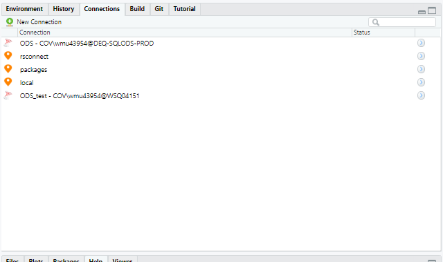

If you have already connected to the ODS environment using the DBI package, you will automatically see this as an available option. If not, see Connect to ODS for more information on making this connection for the first time.

Click on the ODS database connection to show the connection information.

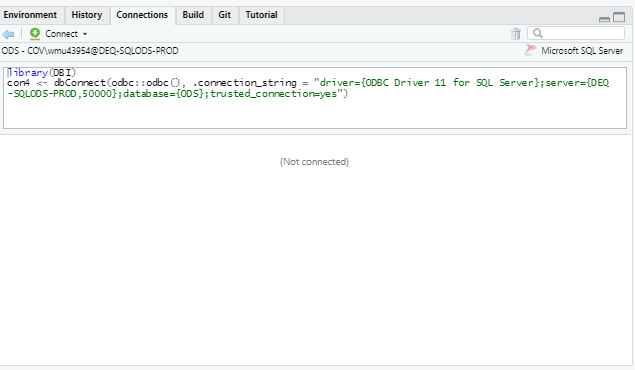

Use the Connect drop down to choose how you want to connect to the database. For this example we will choose ‘R Console’ but other options are helpful for different use cases.

[figure not shown]

The available environments are displayed once the connection is made. This happens almost instantaneously.

[figure not shown]

Click on the drop down arrow next to ODS to show the database structure and what areas you have access to. Your connection may not look identical to the example.

[figure not shown]

Click on any of the areas to preview what data views are available in each area.

[figure not shown]

You can click the drop down arrow next to each data view for details on the variables within the data view as well as each data format.

[figure not shown]

Or you can click the name of the data view to open a preview of the data view (up to first 1,000 rows) in a tabular form in the Viewer Pane. Below we are looking at the first 1,000 rows of the Edas_Benthic_Master_Taxa_View.

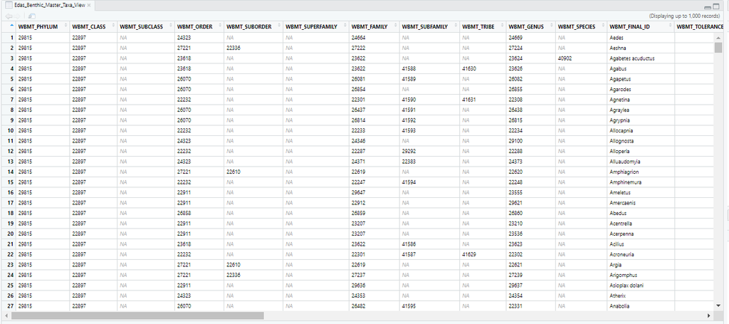

It is important to tell R in your data query not only which data view you are querying but also the area of ODS the data view lives in. Using the pool and dbplyr packages this is very straightforward. Note the in_schema() nested function inside the tbl() function in the example below.

```r
library(tidyverse)
library(pool)
library(dbplyr)

## Connect to ODS production
pool <- dbPool(
  drv = odbc::odbc(),
  Driver = "ODBC Driver 11 for SQL Server",#"SQL Server Native Client 11.0",
  Server= "DEQ-SQLODS-PROD,50000",
  dbname = "ODS",
  trusted_connection = "yes"
)

# Query the entire Edas_Benthic_Master_Taxa_View data view from  the wqm area of ODS
masterTaxaGenus <- pool %>% tbl(in_schema("wqm",  "Edas_Benthic_Master_Taxa_View")) %>%
  as_tibble()

# preview the top 6 rows of the data pulled back from ODS
head(masterTaxaGenus)
```

[output not shown]

As emphasized before, it is prudent to close all database connections established using DBI (the connection method the RStudio Connections pane utilizes). To do this using the GUI, click the “Disconnect From A Connection” button highlighted in red in the picture below.

[figure not shown]

### Data Views Interaction

Another component of any database schema involves how data can be efficiently combined from the various areas of the database. Generally speaking, the way we use data locally in spreadsheets is not how a database stores said data. It is the responsibility of the data query-er to link the datasets they need to make it usable. A full tour of each area of ODS is beyond the scope of these articles, but short overviews of specific ODS areas are discussed in subsequent articles. These areas include:

- Common WQM queries
- Common Benthic queries
- Common WQA queries
- Common TMDL queries

### Data Update Frequency

ODS production is update nightly reflecting any data entered into CEDS the evening before. If you need data immediately after it is entered into CEDS, then CEDS is the only location users can view the data. ODStest is updated infrequently and should not be used for official data queries.